# Basemap_with_Bathymetry

Jordan Watson, NOAA Alaska Fisheries Science Center, jordan.watson@noaa.gov

December 8, 2016

First let’s load some R packages.

IMPORTANT!!!!! Load the tidyverse library first. I have received a funky error message from the map_data() function if I load the “maps” library prior to the “tidyverse” (or “ggplot2”) library.

```r
# IMPORTANT!!!!! Load the tidyverse library first.
# I have received a funky error message from the map_data() function
# if I load the "maps" library prior to the "tidyverse" (or "ggplot2") library.

library(tidyverse) # Contains the ggplot2 and dplyr packages
library(PBSmapping) # From which we'll use the clipPolys function
library(marmap) # From which we get bathymetry
library(maps) # From which we get the world2 basemap
```

# Creating the basemap

Let’s start by creating some latitude / longitude boundaries. The longitude values I’m starting with here are positive but we’ll deal with that later. In this case though, we’re going to create a basemap that spans the dateline and so I’m cheating here.

```r
xmin <- 160
xmax <- 220
ymin <- 50
ymax <- 70
```

I happen to know that the “world2” dataset in the maps package spans the dateline (i.e, it’s centered on the dateline instead of being centered on the Prime Meridian). Let’s load this dataset and automatically use the map_data function from ggplot to convert it to a ggplot data.frame.

```r
myworld <- map_data('world2')
```

As we have done previously, look at the name of the fields created so that we know how to specify the x and y coordinates in the subsequent map.

```r
head(myworld)
```

```
##       long      lat group order region subregion
## 1 290.1009 12.45200     1     1  Aruba      <NA>
## 2 290.1043 12.42300     1     2  Aruba      <NA>
## 3 290.0578 12.43853     1     3  Aruba      <NA>
## 4 289.9958 12.50049     1     4  Aruba      <NA>
## 5 289.9339 12.54697     1     5  Aruba      <NA>
## 6 289.9491 12.59707     1     6  Aruba      <NA>
```

What’s it look like?

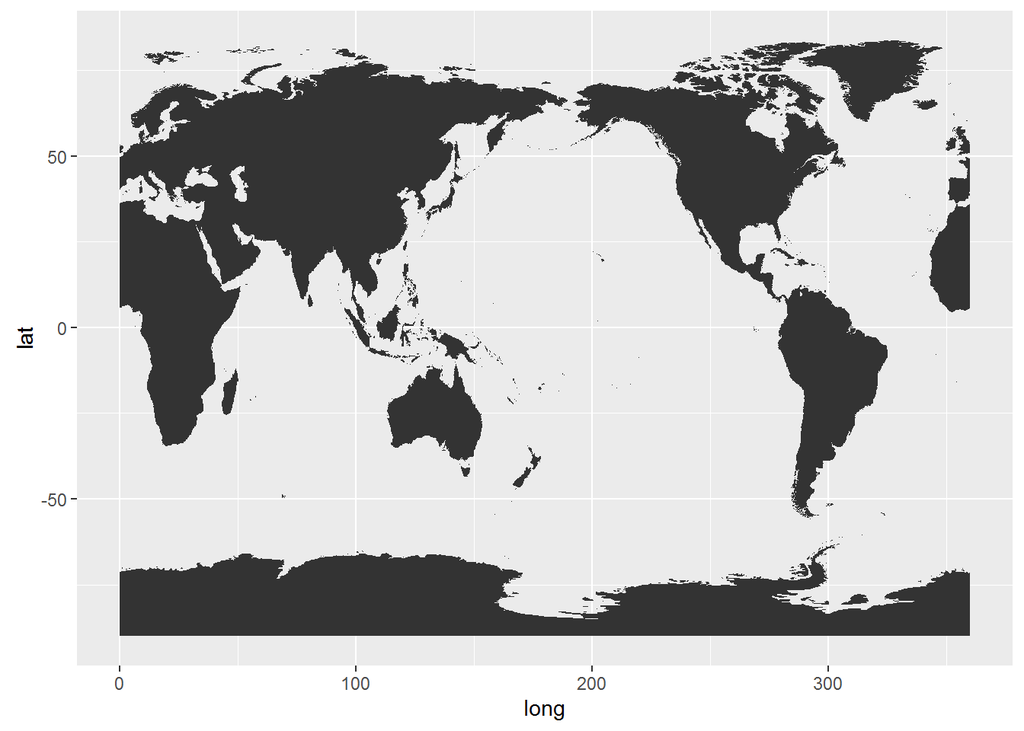

```r
ggplot() + geom_polygon(data=myworld,
                        aes(x=long,y=lat,group=factor(group)))
```

Great, but let’s zoom in using the regional boundaries we defined previously.

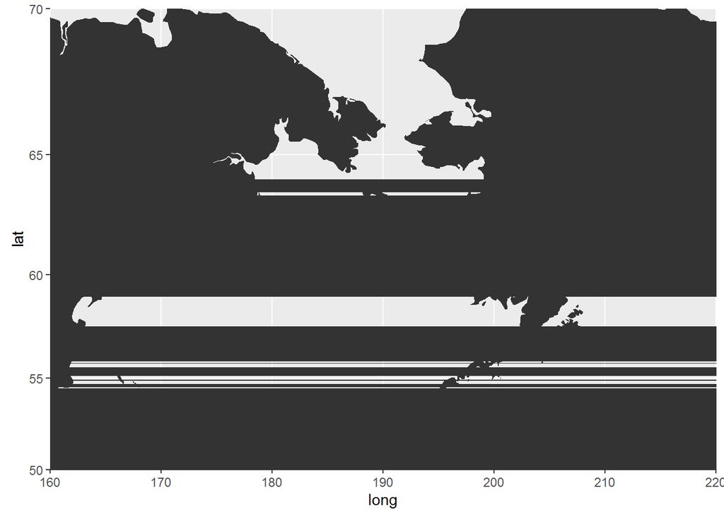

```r
ggplot() + geom_polygon(data=myworld,
                        aes(x=long,y=lat,group=factor(group))) +
  coord_map(xlim=c(xmin,xmax),ylim=c(ymin,ymax))
```

Uh oh!!! What happened? We have seen this before (in the other mapping tutorial). If we try to zoom in on just a portion of the map, R gets confused (sometimes, depending on the zoom) about how to draw polygons that fall partially within and partially beyond our mapping region. So we are going to use the clipPolys function from the PBSmapping package to create new polygons that only span our desired plotting region.

But, the clipPolys function expects different names for the fields (it’s just never easy, is it?). So we rename the fields from myworld to match the expected field names for clipPolys.

```r
names(myworld) <- c("X","Y","PID","POS","region","subregion")
```

You can learn more about clipPolys via ?clipPolys. We need to specify our x and y boundaries so that it can clip the dataset.

```r
myworld <- clipPolys(myworld, xlim=c(xmin,xmax),ylim=c(ymin,ymax), keepExtra=TRUE)
```

Now we should have a map that crosses the dateline and includes Asia.

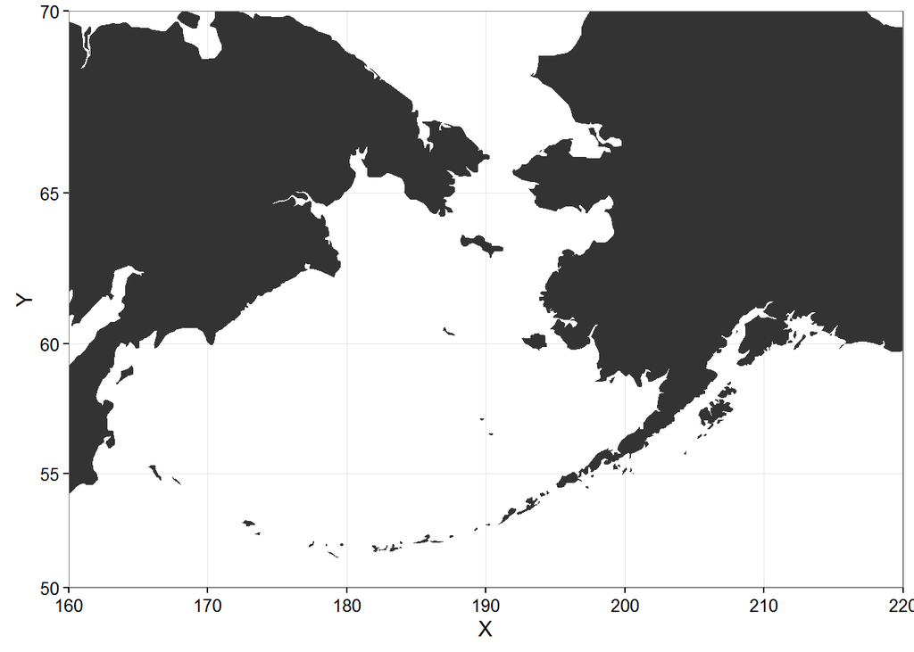

```r
ggplot() +
  geom_polygon(data=myworld,
               aes(x=X,y=Y,group=factor(PID))) +
  coord_map(xlim=c(xmin,xmax),ylim=c(ymin,ymax)) +
  theme_bw()
```

That’s better! Now we have a basemap that is centered on the dateline and really shows the entire Bering Sea.

# Bathymetry

Now we want to add some bathymetry. In the tutorial called “ggplot_lecture” I showed how to add isobath lines for specific depths. In this case, let’s look at adding a bathymetry raster (i.e., pretty map).

When we querying the NOAA bathymetry server for data, we have to know that it’s longitude range goes from -180 to 180. This means that if we want to have continuous data that span the Pacific, we have to make two separate queries - one for the positive and one for the negative longitudes.

```r
mymap1 <- getNOAA.bathy(lon1 = 160, lon2 = 180, lat1 = ymin, lat2 = ymax, resolution = 5)
```

```
## Querying NOAA database ...
## This may take seconds to minutes, depending on grid size
## Building bathy matrix ...
```

```r
mymap2 <- getNOAA.bathy(lon1 = -180, lon2 = -140, lat1 = ymin, lat2 = ymax, resolution = 5)
```

```
## Querying NOAA database ...
## This may take seconds to minutes, depending on grid size
## Building bathy matrix ...
```

So now we have two sets of bathymetry data. Use the fortify.bathy() function to convert the “bathy” object class to a data frame.

```r
temp <- fortify.bathy(mymap2)
```

Let’s see what the longitudes look like:

```r
summary(temp)
```

```
##        x              y               z
##  Min.   :-180   Min.   :50.04   Min.   :-7560
##  1st Qu.:-170   1st Qu.:55.02   1st Qu.:-3559
##  Median :-160   Median :60.00   Median :  -50
##  Mean   :-160   Mean   :60.00   Mean   :-1161
##  3rd Qu.:-150   3rd Qu.:64.98   3rd Qu.:  153
##  Max.   :-140   Max.   :69.96   Max.   : 5403
```

Okay, they’re all negative. Let’s make them positive

```r
temp$x[temp$x<0] <- temp$x[temp$x<0] + 360
```

Now we’ll convert the other bathymetry object (the one with the positive longitudes) to a data.frame and we’ll join it with the one that we just converted to be positive. This way we have a single data.frame with continuous positive longitudes.

```r
newmap <- bind_rows(fortify.bathy(mymap1),temp)
```

BUT, most of the data that we work with have negative longitudes. So now let’s convert the whole thing to be negative. Sure, I could have just converted the positive one to negative originally, but personally I find the extra step acceptable because it was more intuitive for me in the development stages.

```r
newmap$x <- newmap$x-360
```

Now we have a data.frame with all negative longitudes.

```r
summary(newmap)
```

```
##        x              y               z
##  Min.   :-200   Min.   :50.04   Min.   :-7909
##  1st Qu.:-185   1st Qu.:55.02   1st Qu.:-3634
##  Median :-170   Median :60.00   Median :  -49
##  Mean   :-170   Mean   :60.00   Mean   :-1282
##  3rd Qu.:-155   3rd Qu.:64.98   3rd Qu.:  202
##  Max.   :-140   Max.   :69.96   Max.   : 5403
```

Let’s convert this to a “bathy” object.

```r
newmap <- as.bathy(newmap)
```

Let’s also convert the longitudes of our basemap to be negative.

```r
myworld$X <- myworld$X-360
```

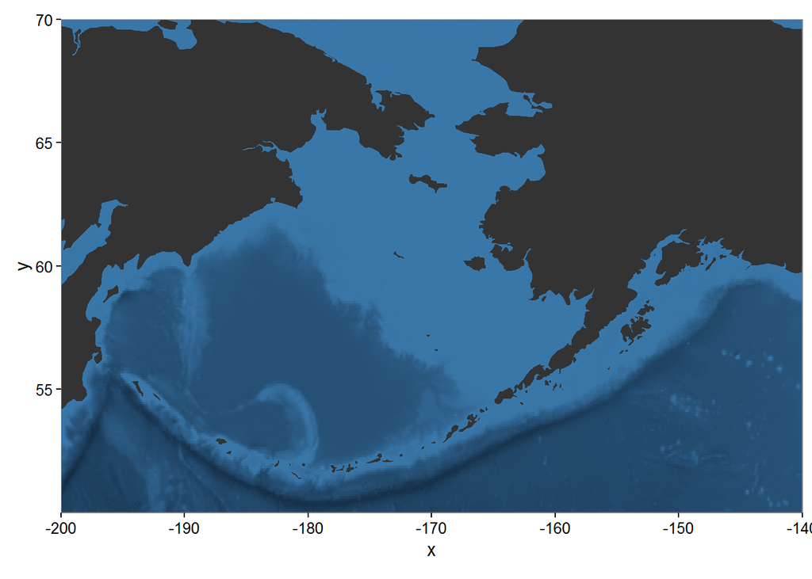

```r
p1 <- autoplot(newmap,geom=c("raster"),coast=FALSE)+
  geom_polygon(data=myworld,
               aes(x=X,y=Y,group=factor(PID))) +
  theme_bw() +
  scale_fill_continuous(guide = FALSE)

p1
```

To add points to the map, you would add a geom_point call that included a data.frame of latitude longitude coordinates. I’ll demonstrate here using the trawl data again (same data used in the dplyr and ggplot tutorials).

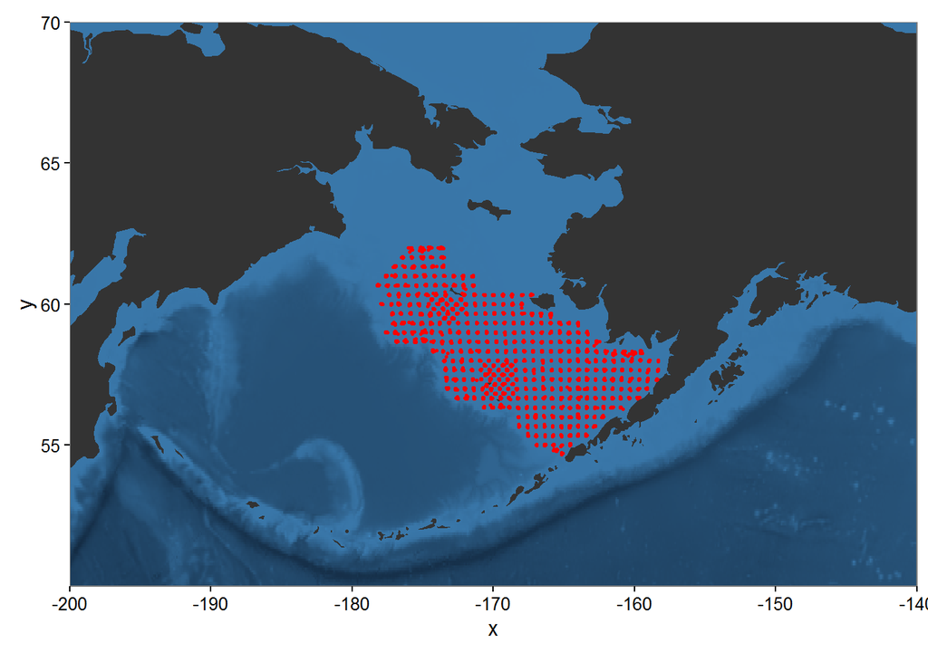

```r
load(url("https://sites.google.com/site/jordantwatson/r/trawl.RData"))
#  The points have to be in a data.frame. Let's filter out the unique trawl survey sites.
trawllocations <- distinct(trawl,LONGITUDE,LATITUDE)

p1 + geom_point(data=trawllocations,aes(x=LONGITUDE,y=LATITUDE),size=0.5,color="red")
```

Say we wanted to save this map as a high resolution file for a paper or poster or something. There are a suite of different file types (e.g., see ?tiff, ?png, ?jpeg, ?pdf). In this case we’ll output a 12“x9” png file at 300 dpi resolution.

```r
png("BathyMap.png",width=12,height=9,units="in",res=300)
print(p1)
dev.off()
```